# Designing a Level

Now that we have the building blocks of our tower defense, we can assemble them together. It is within a level that the *Towers* will battle with *Enemies* to defend the *PlayerBase*.

In our game, players go through waves of enemies while developing their defenses to protect their main building. The player progresses to the next level when there aren’t enemies to fight anymore.

*Levels* tell where and when *Waves* of *Enemies* should start and hold the path to the *PlayerBase*. Each level has different cells available for the *TowerPlacer* to encourage different strategies across levels.

In this chapter, you’ll learn to:

- Design a progress system based on events.
- Provide data to open systems, such as the *TowerPlacer*.
- Build a path finding system.

The *Level* is where every game object we’ve made so far will interact so it has some dependencies. First of all, let’s take a look at the *TowerPlacer*.

The *Level* feeds the *TowerPlacer* with data about the game world. Through the *Level*’s *TileMap*, we’ll get available cells players can place towers.

The *Level* will use a *WaveSpawner* to instantiate *Waves* in run-time. It also feeds the *Waves* with cells that make up the enemy walk path.

To find the shortest available path for *Enemies*, the *Level* uses the *AStarGrid*. It’s an implementation of the A* algorithm using the *TileMap* node. We’ll see how to make it in this lesson.

The *Level* uses a *StartPoint* and a *GoalPoint* in the map to create the walk path. The *GoalPoint* has the *PlayerBase* as a child and leads *Enemies* towards it.

To progress through *Waves* and cutscenes, the *Level* uses an *EventsPlayer*. It’s a class that serializes the *Level*’s events in the form of animations. Each animation changes the

[figure not shown]

`PackedScene` the *WaveSpawner* should spawn. In the end, we also use an animation to trigger the *Level*’s finishing procedure.

Here’s a rough abstraction of these all these relationships.

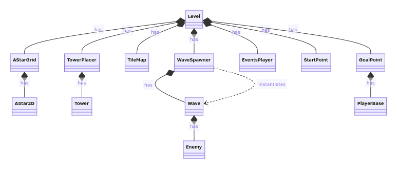

## Designing a tower defense level

Since *Levels* represent our 2D world, let’s use a

[figure not shown]

`Node2D` as root node for our scene. Rename it as *Level* and save the scene as `res://Levels/Level.tscn`.

Our level design system works using indices of a *TileSet* as terrain flags. Double-click `res://Areas/AsteroidSurface/tileset.tres` to open the *Tileset Editor*. Each texture represents a terrain type: - `walkable-path.svg` for enemy walkable cells - `rocks-and-craters.svg` for non placeable cells - `sand.svg` for tower placeable cells

Let’s create a new *TileMap*. Drag and drop the `tileset.tres` to the *TileSet* property. Fill the canvas with *Tower Placeable cells* tiles. Note that the tiles have names describing their function in the tile picker dock.

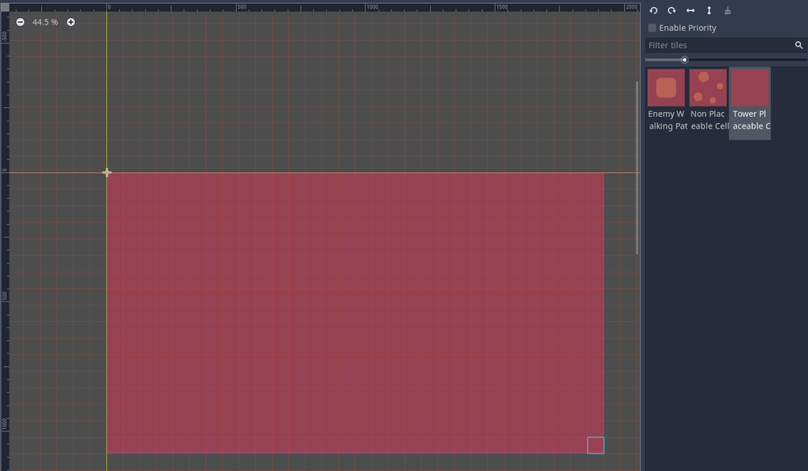

Add an instance of the *PlayerBase* as a *Level*’s child and place it in an interesting place.

Use Godot’s snapping features to keep it inside the *TileSet*’s cells. You can toggle the grid snap by pressing `SHIFT` + `G`. There’s a menu to configure the snap in the 2D editor’s tool shelf. Make sure it’s using `32` pixels on both x and y axes in the *Grid Step* setting. We use `32` instead of `64` so we can place elements in the center of a cell.

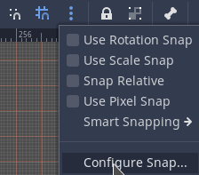

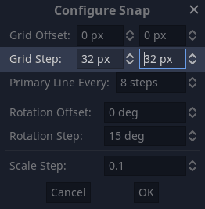

Let’s make our first *Enemy* *Wave*. Add a *Wave* as child of the *Level*. You can create it like we do with built-in node, pressing `CTRL` + `A` and searching for “wave”.

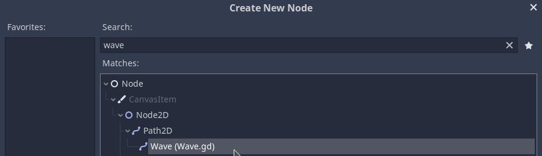

Then, add some instances of *Enemies* as children of the *Wave*. We use three for testing purposes.

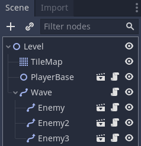

We use the *TileMap* to provide a visual cue of where *Enemies* will walk. For that we can paint some cells with *Enemy Walkable cells* tiles. Here we should design some paths that connect the *Wave* to the *PlayerBase*.

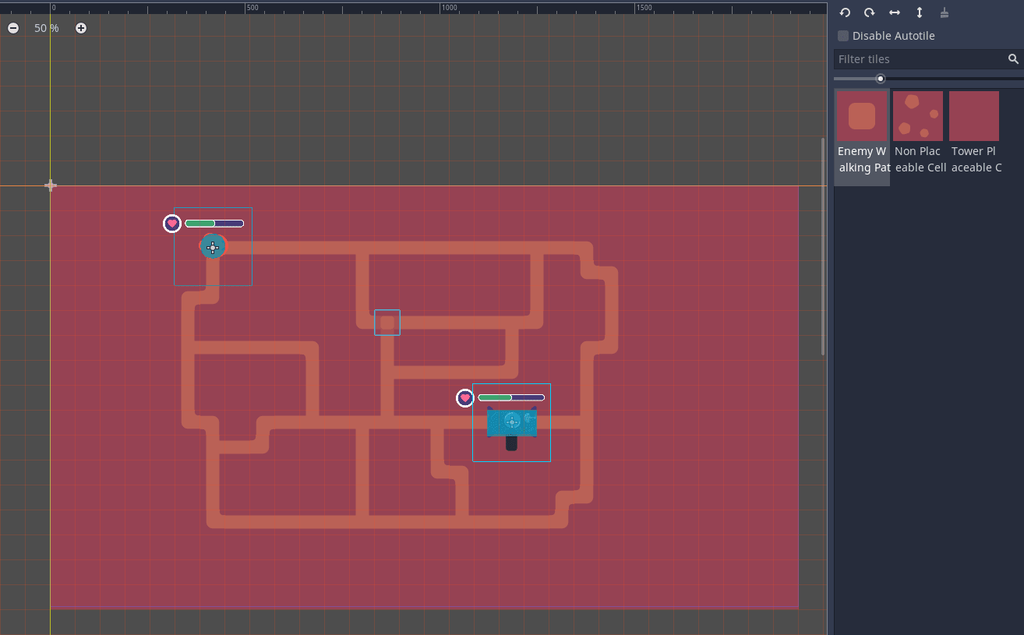

Select the *Wave* and create a new *Curve* on its *Curve* property’s slot. This should prompt the Godot’s path editor.

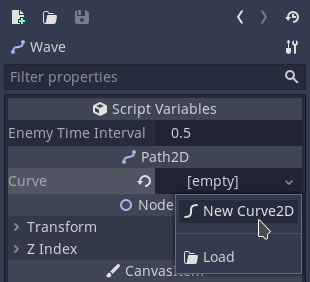

Using the path editor’s tool, draw an interesting path you’d like the *Enemies* to walk.

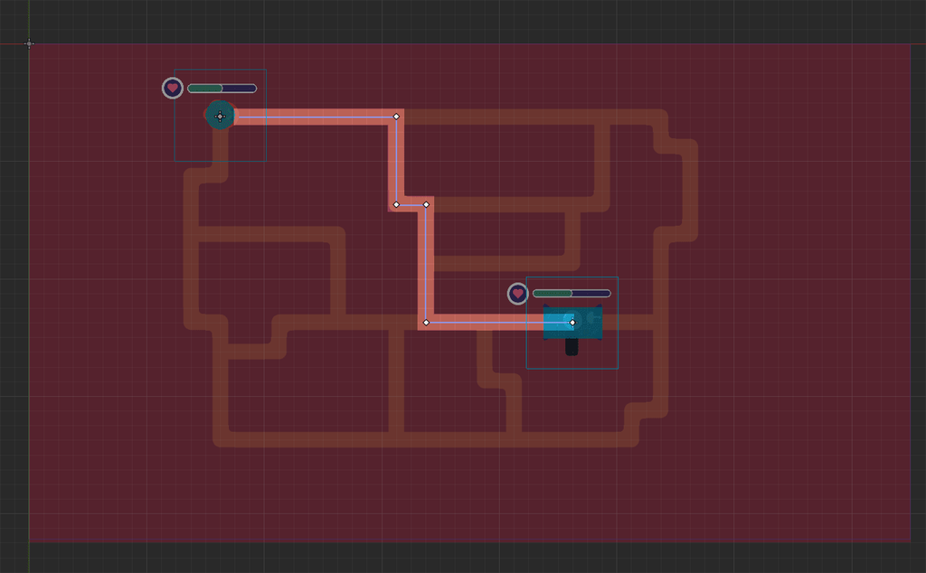

Now that we have a path, we add the option to highlight it to say:

> “Hey! This is where enemies are planning to walk. You might want to place towers near there”.

We’ve created a *PathPreview* node for this. It’s a *Line2D* that glows and fades in and out. You can find the *PathPreview* scene at `res://VFX/PathPreview.tscn`.

Add an instance of the *PathPreview* as child of the *Level*. Using the *Editor*’s built-in line drawing tool, draw over the path you’ve draw for the *Wave*.

You draw over the *Wave* path, you may need to lock it else Godot might think you want to select it. You can find the lock icon in the toolbar.

[figure not shown]

Our players need a way to defend their base! Let’s arm them with our *TowerPlacer*. At the moment, the *TowerPlacer* won’t work because something else should pass *Towers* instances to it. But we test the *Level* anyway. Let’s add *Towers* as children of the *TowerPlacer* ourselves and position them along the map.

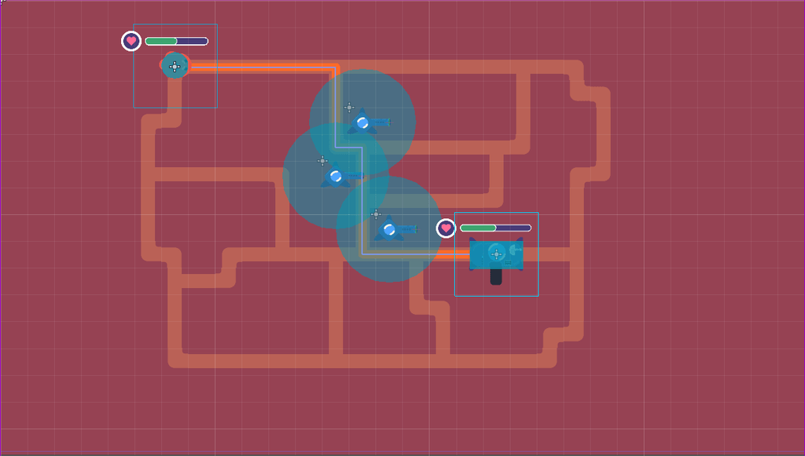

Note that the *PathPreview* is visible below the *Enemies*, *Towers* and the *PlayerBase*. This is because I’ve reorder it to only draw above the *TileMap*. This is how the `SceneTree` looks like after the rearrangement.

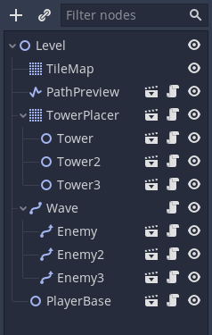

## Testing the Level

Let’s start with the tests!

We have our core game entities in place and ready to interact with each other. If we test the scene now, nothing will happen. Which is a good sign by the way; it means we didn’t run into errors yet.

We start the level using an animation so add an *AnimationPlayer* and create a new animation. You can call it *Test* for now and toggle the *Autoplay on Load* button.

*Towers* will display their interface when we run the scene. This is something we want if they appear through the *TowerPlacer* but we hide the interfaces for clarity in this first test.

We call the method to hide the interface using the *AnimationPlayer*. In the animation editor, add a *Call Method Track* for each of our *Towers*.

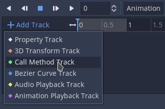

Then right-click in the timeline to add a key calling the `hide_interface()` method.

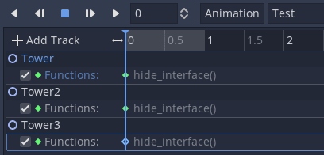

If we test it know, the *Towers* shouldn’t display their interfaces anymore. But our *Enemies* still don’t move.

Back to our test animation, add a *Call Method Track* and select the *Wave* know. We call the `start()` method at the end of the animation so we have one second of delay.

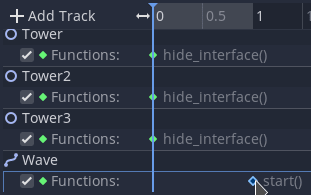

Let’s test it again! You can see that *Enemies* walk through the path we’ve designed. If you want to strengthen the *Enemies*, head back to the editor and increase their *Max Health* property.

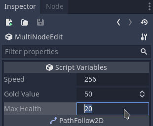

Before we test again, let’s make the *PathPreview* fade out when the *Enemies* start to march. In the test animation, add a *Call Method Track* and select the *PathPreview*. Add a key to the end of the animation and select the `fade_out()` method.

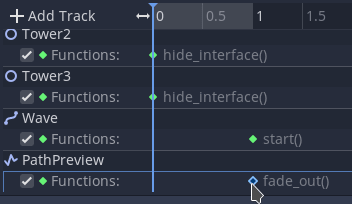

We can see that *Enemies* pass through our defenses and deal damage to the *PlayerBase*.

Let’s decrease the *PlayerBase*’s *Max Health* to see it explode. Drop the *PlayerBase > Max Health* to `1` so a single hit should destroy it.

[figure not shown]

*Perfection*. It could do with some screen shake, but we won’t deal with that.